# **Loan Default Prediction**

## Observations

- The Random Forest is giving a 100% score for all metrics on the training dataset.
- The Random Forest classifier seems to be overfitting the training data. The recall on the training data is 1, while the recall on the test data is only 63% for class 1.
- Accuracy is good for the test data- 89%.

Since this data is imbalance let's see if we are getting better results using a 'balanced' random forest model

## Random Forest model with balanced class weights

```python
# Fitting the random forest tree classifier on the training data
rf_estimator_balanced = RandomForestClassifier(class_weight = 'balanced', random_state = 7)
rf_estimator_balanced.fit(X_train, y_train)
```

```
RandomForestClassifier(class_weight='balanced', random_state=7)
```

```python
# Checking performance on the training data
y_pred_train3 = rf_estimator_balanced.predict(X_train)
metrics_score(y_train, y_pred_train3)
```

```
              precision    recall  f1-score   support

           0       1.00      1.00      1.00      3355
           1       1.00      1.00      1.00       817

    accuracy                           1.00      4172
   macro avg       1.00      1.00      1.00      4172
weighted avg       1.00      1.00      1.00      4172
```

```
              precision    recall  f1-score   support

           0       0.90      0.96      0.93      1416
           1       0.81      0.60      0.69       372

    accuracy                           0.89      1788
   macro avg       0.86      0.78      0.81      1788
weighted avg       0.88      0.89      0.88      1788
```

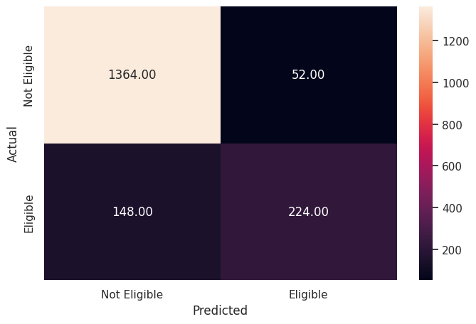

```python
# Checking performance on the testing data
y_pred_test3 = rf_estimator_balanced.predict(X_test)
metrics_score(y_test, y_pred_test3)
```

```python
rf_estimator_balanced_test = model_performance_classification(rf_estimator_balanced,X_test,y_test)
rf_estimator_balanced_test
```

|  | Precision | Recall | Accuracy |
| --- | --- | --- | --- |
| 0 | 0.856855 | 0.782714 | 0.888143 |

## Observations

- The balanced Random Forest classifier is also overfitting the training data. The recall on the training data is 1, while the recall on the test data is only 60% for class 1 compared to 63% in the baseline model
- The balanced random forest did not improve the model performance.
- The balanced Random Forest is also giving a 100% score for all metrics on the training dataset.
- Precision is good for the test data- 81%
- Recall is 60% for the test data

### **Random Forest Classifier Hyperparameter Tuning**

**1. Comparison of various techniques and their relative performance based on chosen Metric (Measure of success):**

- How do different techniques perform? Which one is performing relatively better? Is there scope to improve the performance further?

**2. Refined insights:**

- What are the most meaningful insights relevant to the problem?

**3. Proposal for the final solution design:**

- What model do you propose to be adopted? Why is this the best solution to adopt?

## Tuning the Random Forest

```python
# Choose the type of classifier
rf_estimator_tuned = RandomForestClassifier(class_weight = 'balanced', random_state = 1)

# Grid of parameters to choose from
params_rf = {
        "n_estimators": [100, 250, 500],
        "min_samples_leaf": np.arange(1, 4, 1),
        "max_features": [0.7, 0.9, 'auto'],
}


# Type of scoring used to compare parameter combinations - recall score for class 1
scorer = metrics.make_scorer(recall_score, pos_label = 1)

# Run the grid search
grid_obj = GridSearchCV(rf_estimator_tuned, params_rf, scoring = scorer, cv = 5)

grid_obj = grid_obj.fit(X_train, y_train)

# Set the classifier to the best combination of parameters
rf_estimator_tuned = grid_obj.best_estimator_
```

```python
rf_estimator_tuned.fit(X_train, y_train)
```

```
RandomForestClassifier(class_weight='balanced', max_features=0.7,
                       min_samples_leaf=np.int64(3), n_estimators=500,
                       random_state=1)
```

```
              precision    recall  f1-score   support

           0       1.00      0.97      0.98      3355
           1       0.88      0.98      0.93       817

    accuracy                           0.97      4172
   macro avg       0.94      0.97      0.95      4172
weighted avg       0.97      0.97      0.97      4172
```

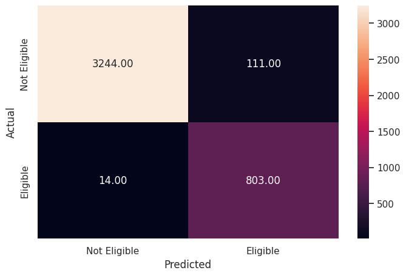

```python
# Checking performance on the training data
y_pred_train_rf_tuned = rf_estimator_tuned.predict(X_train)
metrics_score(y_train, y_pred_train_rf_tuned)
```

```
              precision    recall  f1-score   support

           0       0.93      0.93      0.93      1416
           1       0.74      0.74      0.74       372

    accuracy                           0.89      1788
   macro avg       0.84      0.84      0.84      1788
weighted avg       0.89      0.89      0.89      1788
```

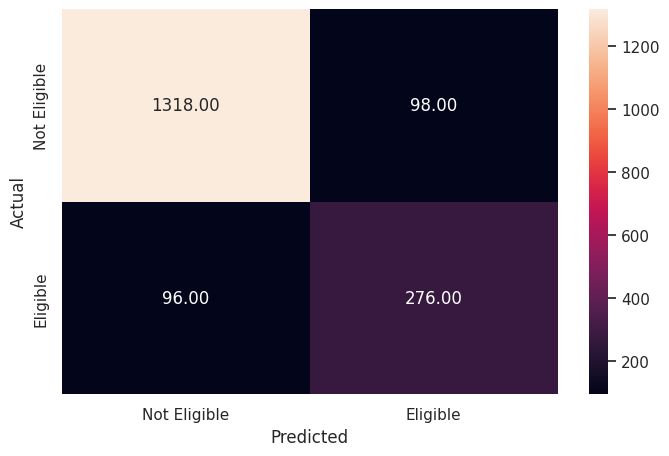

```python
# Checking performance on the test data
y_pred_test_rf_tuned = rf_estimator_tuned.predict(X_test)
metrics_score(y_test, y_pred_test_rf_tuned)
```

```python
rf_estimator_tuned_test = model_performance_classification(rf_estimator_tuned, X_test, y_test)
rf_estimator_tuned_test
```

|  | Precision | Recall | Accuracy |
| --- | --- | --- | --- |
| 0 | 0.835038 | 0.836363 | 0.891499 |

## Observations

- The tuned random forest improves the model performance.
- The tuned Random Forest is not giving a 100% score for all metrics on the training dataset- there is less overfitting of the training data
- The recall on the training data is 98%, while the recall on the test data is only 74% for class 1 compared to 63% in the baseline model and 60% for the balanced random forest model.
- Precision for the test set is 74%, it has decreased compared to the baseline model and balanced model at 81%, this is expected as we were trying to reduce overfitting
- In our case, we are assessing the model mainly by the recall score. in the tuned random forest we got the lowest number of false negative cases so far.

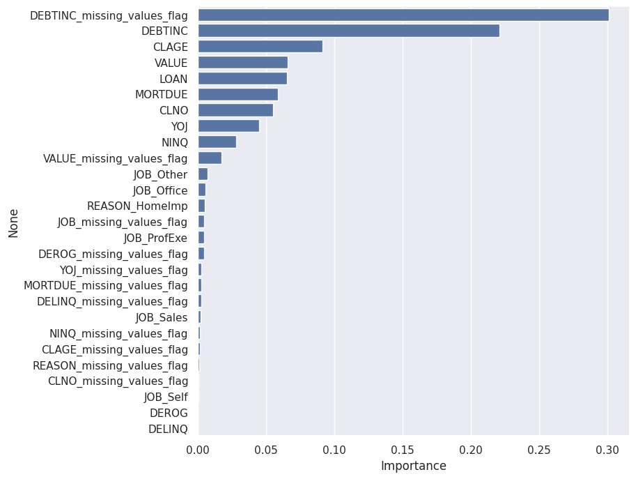

```python
# Plotting feature importance
importances = rf_estimator_tuned.feature_importances_

columns = X.columns

importance_df = pd.DataFrame(importances, index = columns, columns = ['Importance']).sort_values(by = 'Importance', ascending = False)

plt.figure(figsize = (8, 8))

sns.barplot(x='Importance', y=importance_df.index, data=importance_df)
```

## Observations

- The feature importance plot for the random forest suggests that the DEBTINC_missing_values_flag followed by DEBTINC are the most important features. This is similar to the feature importance of the decision tree.
- Other important features are CLAGE, VALUE, LOAN, MORTDUE, and CLNO

## Boosting Models

```python
# Installing the xgboost library using the 'pip' command.
!pip install xgboost
```

```python
# Importing the AdaBoostClassifier and GradientBoostingClassifier [Boosting]
from sklearn.ensemble import AdaBoostClassifier, GradientBoostingClassifier

# Importing the XGBClassifier from the xgboost library
from xgboost import XGBClassifier
```

```python
# Adaboost Classifier
adaboost_model = AdaBoostClassifier(random_state = 1)

# Fitting the model
adaboost_model.fit(X_train, y_train)

# Model Performance on the test data
adaboost_model_perf_test = model_performance_classification(adaboost_model,X_test,y_test)

adaboost_model_perf_test
```

|  | Precision | Recall | Accuracy |
| --- | --- | --- | --- |
| 0 | 0.83827 | 0.768783 | 0.878635 |

```python
# Gradient Boost Classifier
gbc = GradientBoostingClassifier(random_state = 1)

# Fitting the model
gbc.fit(X_train, y_train)

# Model Performance on the test data
gbc_perf_test = model_performance_classification(gbc, X_test, y_test)

gbc_perf_test
```

|  | Precision | Recall | Accuracy |
| --- | --- | --- | --- |
| 0 | 0.852236 | 0.783989 | 0.887025 |

```python
# XGBoost Classifier
xgb = XGBClassifier(random_state = 1, eval_metric = 'logloss')

# Fitting the model
xgb.fit(X_train,y_train)

# Model Performance on the test data
xgb_perf_test = model_performance_classification(xgb,X_test,y_test)

xgb_perf_test
```

|  | Precision | Recall | Accuracy |
| --- | --- | --- | --- |
| 0 | 0.868268 | 0.812921 | 0.899888 |

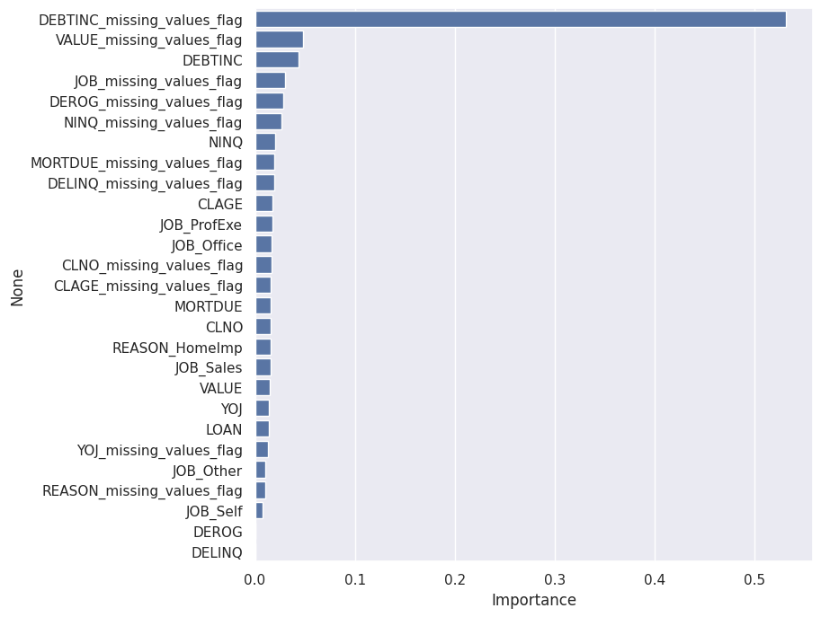

```python
importances = xgb.feature_importances_
columns = X.columns
importance_df = pd.DataFrame(importances, index = columns, columns = ['Importance']).sort_values(by = 'Importance', ascending = False)
plt.figure(figsize = (8, 8))
sns.barplot(x='Importance', y=importance_df.index, data=importance_df)
```

## Observations

- Again we can see that the DEBTINC_missing_value has the weights the most on the prediction to default a loan. The other features are less important according to this model.

```python
from sklearn.neighbors import KNeighborsClassifier
```

```python
knn = KNeighborsClassifier()

# We select the optimal value of K for which the error rate is the least in the validation data
# Let us loop over a few values of K to determine the optimal value of K

train_error = []
test_error = []
knn_many_split = {}
error_df_knn = pd.DataFrame()
features = X.columns

for k in range(1, 15):
    train_error = []

    test_error = []

    lista = []

    knn = KNeighborsClassifier(n_neighbors = k)

    for i in range(30):
        x_train_new, x_val, y_train_new, y_val = train_test_split(X_train, y_train, test_size = 0.30)

        # Fitting K-NN on the training data
        knn.fit(x_train_new, y_train_new)

        # Calculating error on the training data and the validation data
        train_error.append(1 - knn.score(x_train_new, y_train_new))

        test_error.append(1 - knn.score(x_val, y_val))

    lista.append(sum(train_error)/len(train_error))

    lista.append(sum(test_error)/len(test_error))

    knn_many_split[k] = lista

knn_many_split
```

```
{1: [0.0, 0.23112353567625135],
 2: [0.1282077625570776, 0.1848509052183174],
 3: [0.12263698630136988, 0.20095846645367416],
 4: [0.15208904109589044, 0.18711395101171463],
 5: [0.14899543378995433, 0.19337060702875403],
 6: [0.16369863013698632, 0.18567625133120338],
 7: [0.16121004566210048, 0.1861554845580405],
 8: [0.17002283105022833, 0.18594249201277957],
 9: [0.16767123287671234, 0.18383919062832796],
 10: [0.17563926940639268, 0.18328008519701816],
 11: [0.17236301369863008, 0.1838125665601704],
 12: [0.17727168949771688, 0.18703407880724177],
 13: [0.17599315068493157, 0.1854898828541001],
 14: [0.1800799086757991, 0.18801916932907356]}
```

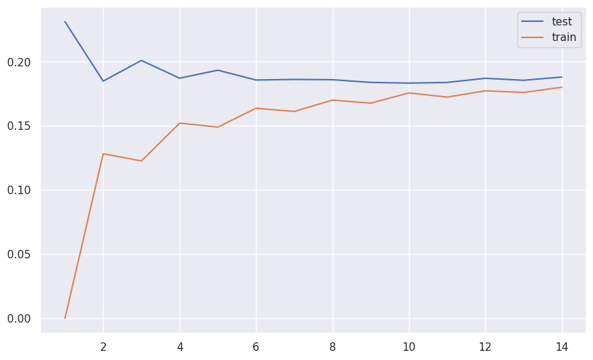

```python
kltest = []

vltest = []

for k, v in knn_many_split.items():
    kltest.append(k)

    vltest.append(knn_many_split[k][1])

kltrain = []

vltrain = []

for k, v in knn_many_split.items():
    kltrain.append(k)

    vltrain.append(knn_many_split[k][0])

# Plotting K vs Error
plt.figure(figsize = (10, 6))

plt.plot(kltest, vltest, label = 'test' )

plt.plot(kltrain, vltrain, label = 'train')

plt.legend()

plt.show()
```

## Observations

- We can see that the test error (error on the validation data) is more or less similar for K greater than or equal to 6. But the training error keeps increasing with increasing K.
- This implies that we would get a lower train and test error if we choose K = 6.
- So, let's fit the K-NN model with K=6 on the entire training set.

```python
# Define K-NN model

knn = KNeighborsClassifier(n_neighbors = 6)
```

```python
# Fitting data to the K-NN model

knn.fit(X_train,y_train)
```

```
KNeighborsClassifier(n_neighbors=6)
```

```
              precision    recall  f1-score   support

           0       0.84      0.99      0.91      3355
           1       0.84      0.22      0.35       817

    accuracy                           0.84      4172
   macro avg       0.84      0.61      0.63      4172
weighted avg       0.84      0.84      0.80      4172
```

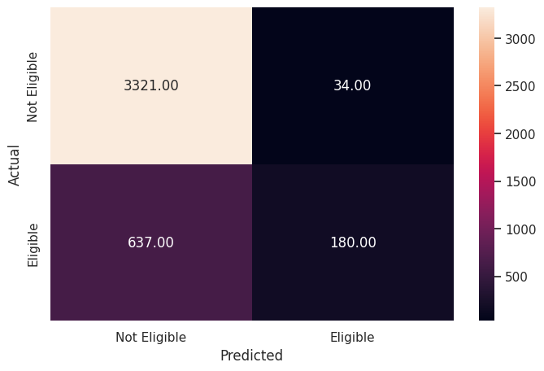

```python
# Checking the performance of K-NN model on the training data
y_pred_train_knn = knn.predict(X_train)

metrics_score(y_train, y_pred_train_knn)
```

```
              precision    recall  f1-score   support

           0       0.82      0.99      0.89      1416
           1       0.76      0.16      0.26       372

    accuracy                           0.81      1788
   macro avg       0.79      0.57      0.58      1788
weighted avg       0.80      0.81      0.76      1788
```

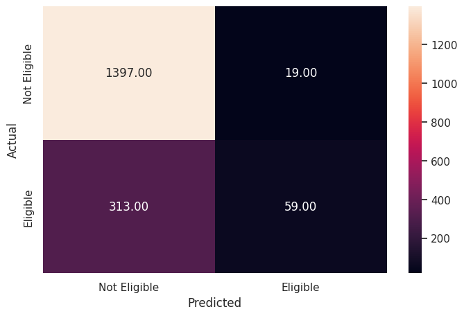

```python
# Checking the performance of K-NN model on the testing data
y_pred_test_knn = knn.predict(X_test)

metrics_score(y_test, y_pred_test_knn)
```

```python
knn_test = model_performance_classification(knn, X_test, y_test)
knn_test
```

|  | Precision | Recall | Accuracy |
| --- | --- | --- | --- |
| 0 | 0.786685 | 0.572592 | 0.814318 |

## Observations

- The model is not performing well.
- The Recall score on the train and test sets are extremely low.
- Let's try to tune this model.

```python
params_knn = {'n_neighbors': np.arange(3, 15), 'weights': ['uniform', 'distance'], 'p': [1, 2]}

grid_knn = GridSearchCV(estimator = knn, param_grid = params_knn, scoring = 'recall', cv = 10)

model_knn = grid_knn.fit(X_train,y_train)

knn_estimator = model_knn.best_estimator_

print(knn_estimator)
```

```
KNeighborsClassifier(n_neighbors=np.int64(3), p=1, weights='distance')
```

We have found the best hyperparameters for the K-NN classifier. Let's use these parameters to build the new K-NN model and find the recall of that model.

```python
# Fit the best estimator on the training data
knn_estimator.fit(X_train, y_train)
```

```
KNeighborsClassifier(n_neighbors=np.int64(3), p=1, weights='distance')
```

```python
# Checking train data
y_pred_train_knn_estimator = knn_estimator.predict(X_train)

metrics_score(y_train, y_pred_train_knn_estimator)
```

```
              precision    recall  f1-score   support

           0       1.00      1.00      1.00      3355
           1       1.00      1.00      1.00       817

    accuracy                           1.00      4172
   macro avg       1.00      1.00      1.00      4172
weighted avg       1.00      1.00      1.00      4172
```

```
              precision    recall  f1-score   support

           0       0.83      0.94      0.88      1416
           1       0.53      0.27      0.36       372

    accuracy                           0.80      1788
   macro avg       0.68      0.61      0.62      1788
weighted avg       0.77      0.80      0.77      1788
```

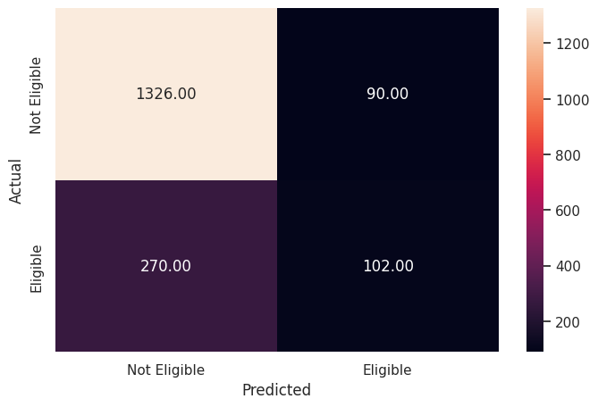

```python
# Checking test data
y_pred_test_knn_estimator = knn_estimator.predict(X_test)

metrics_score(y_test, y_pred_test_knn_estimator)
```

```python
knn_tuned_test = model_performance_classification(knn_estimator, X_test, y_test)
knn_tuned_test
```

|  | Precision | Recall | Accuracy |
| --- | --- | --- | --- |
| 0 | 0.681039 | 0.605317 | 0.798658 |